# S7: k Nearest Neighbors

# Visualizing the result

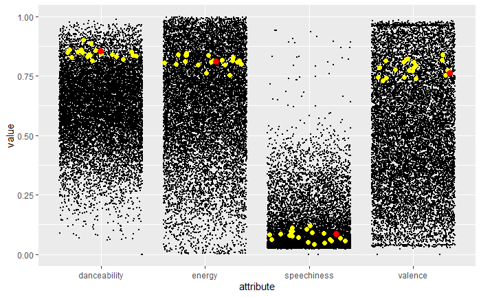

```r
knn_data <- songs %>%                                   # Extracting data in tody format!
    select(var_dist, "song_name") %>%
    gather(key = attribute, value = value, -song_name)
knn_data %>%                                            # Plotting
    ggplot(aes(x = attribute, y = value)) + geom_jitter(size = 0.5) +
    geom_jitter(data = knn_data %>% filter(song_name %in% neighbor_names), color = "yellow", size = 2) +
    geom_jitter(data = knn_data %>% filter(song_name == "Poker Face"), color = "red", size = 3)
```

The job in incredibly well done!

Ok, but what if we want to include another variable, like **tempo**? Easy: add it to the list of variables and scale it via **mutate**()!

```r
var_dist2 <- c("danceability", "energy", "speechiness", "valence", "tempo")  # Adding the tempo
songs2 <- songs %>% mutate(tempo = tempo / 250)                                          # Scaling the tempo
target2 <- target %>% mutate(tempo = tempo / 250)
head(songs2) %>% select(song_name, artist, duration, danceability, tempo)                # Check scale
```

| song_name | artist | duration | danceability | tempo |
| --- | --- | --- | --- | --- |
| Boulevard of Broken Dreams | Green Day | 262 | 0.496 | 0.668 |
| In The End | Linkin Park | 217 | 0.542 | 0.420 |
| Seven Nation Army | The White Stripes | 232 | 0.737 | 0.496 |
| By The Way | Red Hot Chili Peppers | 217 | 0.451 | 0.488 |
| How You Remind Me | Nickelback | 224 | 0.447 | 0.688 |
| Bring Me To Life | Evanescence | 236 | 0.316 | 0.760 |

Ok, we are ready for a second round of *k*-NN.

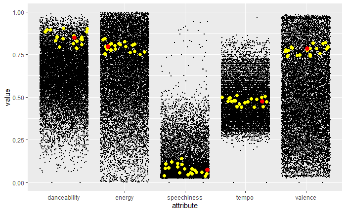

```r
neighbors2 <- get.knnx(data = songs2 %>% select(var_dist2),                              # New data source!
                      query = target2 %>% select(var_dist2),                             # Target
                      k = 20,                                                            # Nb of neighbors
                      algorithm = "brute")                                               # Algo type
neighbor_names2 <- songs2[neighbors2$nn.index,] %>% pull(song_name)
knn_data2 <- songs2 %>%
    select(var_dist2, "song_name") %>%
    gather(key = attribute, value = value, -song_name)
knn_data2 %>%
    ggplot(aes(x = attribute, y = value)) + geom_jitter(size = 0.5) +
    geom_jitter(data = knn_data2 %>% filter(song_name %in% neighbor_names2), color = "yellow", size = 2) +
    geom_jitter(data = knn_data2 %>% filter(song_name == "Poker Face"), color = "red", size = 3)
```

# Predictive k-NN

Nearest neighbors can be used for prediction purposes. We have used 5 variables to detect proximity. Let’s see if they can help predict the popularity of the song. Let’s compute the average popularity of *Poker Face*’s neighbors.

```r
# The number we are trying to predict:
songs %>% filter(song_name == "Poker Face") %>% pull(popularity)
```

```
[1] 31
```

```r
songs[neighbors2$nn.index,] %>%
    pull(popularity) %>%
    mean()
```

```
[1] 44.7
```

Does weighting help improve the forecast?

```r
library(magrittr)
songs[neighbors2$nn.index,] %>%
    pull(popularity) %>%
    multiply_by(exp(-neighbors2$nn.dist)/mean(exp(-neighbors2$nn.dist))) %>%  # Pipe multiplication!
    mean()
```

```
[1] 44.69537
```

Not really.  
What this means is that *Poker Face* is much less populat than songs that have very similar characteristics.